# Univerzita Jana Evangelisty Purkyně v Ústí nad Labem

## Přírodovědecká fakulta

# OLAP a PostgreSQL + Metabase

**Rok vytvoření:** 2025

**Autor:** Marie Kleckerová

**Předmět:** KI/ODM

**Studijní program:** Informatika

**Studijní obor:** Matematika ve firmách a veřejné správě

# Obsah

# 1. Úvod

Cílem této práce je prakticky vyzkoušet práci s nástroji pro **data warehouse** (DWH) a **OLAP analýzu** v rámci předmětu **KI/ODM**. Pro realizaci úkolu jsem zvolila databázový systém **PostgreSQL** jako platformu pro ukládání dat a nástroj **Metabase** jako prostředí pro vizualizaci a analytické dotazy.

Při výběru technologií jsem zvažovala více možností. **Microsoft SQL Server** jsem kvůli omezené podpoře na macOS zavrhla hned na začátku. Dále jsem zkoušela **cube.js**, který nabízí moderní přístup k OLAP analýze, ale práce s terminálem, Node.js a Javou byla zbytečně komplikovaná vzhledem k rozsahu této práce. **icCube** mě zaujal jako profesionální nástroj, ale přístup do něj vyžadoval schválení, na které jsem v době zpracování stále čekala. Proto jsem nakonec zvolila **PostgreSQL**, který je spolehlivý, otevřený a dobře funguje i na macOS. Jako OLAP-like nástroj jsem zvolila **Metabase** – díky jednoduchému nasazení, intuitivnímu rozhraní a dobré integraci s PostgreSQL.

Součástí práce je:  
- **instalace a nastavení** PostgreSQL a Metabase,  
- výběr a úprava **vhodné datové sady**,  
- **návrh a implementace** datového skladu ve struktuře hvězdicového schématu (star schema),  
- vytvoření analytických **dotazů** a vizualizací v Metabase,  
- aplikace metod **data miningu** na zvolených datech.

Výsledkem je propojený systém umožňující analytickou práci nad datovou strukturou a příprava výstupů pro prezentaci.

# 2. Instalace DBMS a OLAP nástroje

Pro realizaci úkolu jsem použila databázový systém **PostgreSQL** a analytický nástroj **Metabase**.

## 2.1 Instalace PostgreSQL

PostgreSQL je open-source relační databázový systém známý svou stabilitou, robustností a podporou pokročilých funkcí. Slouží jako úložiště pro strukturovaná data a umožňuje práci s relačními daty pomocí jazyka SQL.

PostgreSQL jsem nainstalovala pomocí oficiální instalace pro můj operační systém dostupné na https://www.postgresql.org/download/.

Postup instalace:

1. Nejprve jsem zkontrolovala, zda mám nainstalovaný Homebrew, pomocí příkazu:

   ```bash
   brew --version
   ```

2. Pokud Homebrew nebyl nainstalovaný, spustila jsem instalaci příkazem:

   ```bash
   /bin/bash -c "\$(curl -fsSL
   <https://raw.githubusercontent.com/Homebrew/install/HEAD/install.sh>"
   ```

3. Poté jsem nainstalovala PostgreSQL příkazem:

   ```bash
   brew install postgresql
   ```

4. Po dokončení instalace jsem spustila PostgreSQL server:

   ```bash
   brew services start postgresql
   ```

5. Přihlášení do PostgreSQL příkazovou řádkou: `bash psql postgres`

(pro přihlášení bylo potřeba zadat heslo nastavené při instalaci)

Pro správu databáze jsem také nainstalovala grafické rozhraní **pgAdmin**, které umožňuje snadnou správu databází přes webové rozhraní. Instalace pgAdmin pro macOS je dostupná na stránce: https://www.pgadmin.org/download/pgadmin-4-macos/

## 2.2 Instalace Metabase (OLAP nástroj)

**Metabase** je open-source nástroj pro **business intelligence** a **datovou analytiku**, který umožňuje snadné vizualizace a tvorbu dashboardů bez nutnosti pokročilého programování. Slouží jako **OLAP nástroj** pro vytváření analytických dotazů nad databází PostgreSQL.

Metabase jsem nainstalovala pomocí Dockeru, což je jednoduchý způsob, jak spustit aplikaci v izolovaném kontejneru.

### Instalace Metabase přes Docker na macOS:

1. Nejprve jsem zkontrolovala, zda mám nainstalovaný Docker, pomocí příkazu:

   ```bash
   docker --version
   ```

2. Pokud by Docker nebyl nainstalovaný, stáhla bych ho a nainstalovala z oficiálních stránek:

   https://www.docker.com/products/docker-desktop
3. Po úspěšné instalaci a spuštění **Docker Desktop** jsem stáhla a spustila **Metabase** příkazem:

   ```bash
   docker run -d -p 3000:3000 --name metabase metabase/metabase
   ```

Tímto příkazem se spustí Metabase na **portu 3000**. Aplikace je následně přístupná ve webovém prohlížeči na adrese:

http://localhost:3000

Po spuštění jsem prošla úvodní konfigurací (nastavení admin účtu, připojení databáze).

# Výběr a popis datové sady

Pro účely této práce jsem si vybrala datovou sadu z portálu [Kaggle](https://www.kaggle.com/datasets/vivek468/superstore-dataset-final). Konkrétně jsem použila dataset s názvem **“Superstore Dataset Final”**, který obsahuje údaje o prodejích a ziscích velkého maloobchodního řetězce v letech 2014 až 2017.

Dataset obsahuje **9994** řádků a **21** sloupců. Každý řádek představuje jednu transakci. Data jsou uložena v jednom souboru ve formátu **CSV**.

Odkaz na dataset:  
https://www.kaggle.com/datasets/vivek468/superstore-dataset-final

Dataset obsahuje následující sloupce:  
- **Row ID**: unikátní identifikátor řádku  
- **Order ID**: identifikátor objednávky  
- **Order Date**: datum objednávky  
- **Ship Date**: datum odeslání  
- **Ship Mode**: způsob dopravy (např. Standard Class, Second Class)  
- **Customer ID**: identifikátor zákazníka  
- **Customer Name**: jméno zákazníka  
- **Segment**: segment trhu (např. Consumer, Corporate)  
- **Country**: země  
- **City**: město  
- **State**: stát  
- **Postal Code**: poštovní směrovací číslo  
- **Region**: region (např. East, West)  
- **Product ID**: identifikátor produktu  
- **Category**: kategorie produktu (např.Furniture, Office Supplies)  
- **Sub-Category**: podkategorie produktu  
- **Product Name**: název produktu  
- **Sales**: tržby  
- **Quantity**: množství  
- **Discount**: sleva  
- **Profit**: zisk

Zvolený dataset jsem si vybrala, protože obsahuje **časovou dimenzi (Order Date)**, která je nezbytná pro budování datového skladu. Zároveň umožňuje vytvořit více dimenzí pro analýzu (čas, produkt, zákazník).

Pro zpracování dat jsem se rozhodla implementovat **data warehouse (DWH)** a navrhnout jeho strukturu ve formě **hvězdicového schématu (star schema)**.

# 4. Krok 4 – Úprava a transformace dat

Původní dataset byl uložen v jednom souboru ve formátu **CSV**, obsahoval **9994** řádků a **21** sloupců. Pro účely budování datového skladu bylo potřeba data očistit a transformovat do podoby vhodné pro hvězdicové schéma (**star schema**).

## 4.1 Čištění dat

Pro zajištění kvality dat jsem provedla následující kroky. Čištění bylo realizováno pomocí skriptů v jazyce **Python** a knihovny **pandas**.

### Kontrola a odstranění duplicitních řádků:

Nejprve byly zkontrolovány a odstraněny duplicitní řádky.

```python
import pandas as pd

df = pd.read_csv('/Users/majdikleckerova/Desktop/OLAP – Superstore Sales/Sample - Superstore.csv')
duplicates = df.duplicated().sum()
df_cleaned = df.drop_duplicates()
```

### Kontrola chybějících hodnot:

Dále byly zkontrolovány sloupce s chybějícími hodnotami a odstraněny řádky, které měly v důležitých sloupcích chybějící data.

```python
missing_values = df_cleaned.isnull().sum()
print("Chybějící hodnoty:\n", missing_values)
df_cleaned = df_cleaned.dropna(subset=['Customer ID'])
```

### Ověření platných hodnot:

Byly ověřeny hodnoty v numerických sloupcích a odstraněny řádky se zápornými hodnotami v poli Quantity a Sales.

```python
df_cleaned = df_cleaned[df_cleaned['Quantity'] >= 0]
df_cleaned = df_cleaned[df_cleaned['Sales'] >= 0]
```

## 4.2 Transformace dat

Po očištění dat jsem přistoupila k transformaci datasetu do **čtyř** tabulek odpovídajících hvězdicovému schématu: `dim_customer`, `dim_date`, `dim_product` a `fact_sales`.

### Vytvoření tabulky dim_customer

Tabulka `dim_customer` obsahuje unikátní zákazníky. Každému zákazníkovi jsem přiřadila unikátní klíč `customer_key`.

Sloupce tabulky `dim_customer` jsou: `customer_key` (primární klíč), `customer_id`, `customer_name`, `segment`, `city`, `state`, `region`, `country`, `postal_code`.

```python
df_customers = df_cleaned[['Customer ID', 'Customer Name', 'Segment', 'City', 'State', 'Region', 'Country', 'Postal Code']].drop_duplicates().reset_index(drop=True)
df_customers['customer_key'] = df_customers.index + 1
df_customers = df_customers.rename(columns={
    'Customer ID': 'customer_id',
    'Customer Name': 'customer_name',
    'Segment': 'segment',
    'City': 'city',
    'State': 'state',
    'Region': 'region',
    'Country': 'country',
    'Postal Code': 'postal_code'
})
df_customers.to_csv('dim_customer.csv', index=False)
```

### Vytvoření tabulky dim_date

Tabulka `dim_date` obsahuje unikátní datum objednávky a další atributy, jako je den, měsíc, rok a čtvrtletí. Každému datu jsem přiřadila unikátní `date_id`.

Sloupce tabulky `dim_date` jsou: `date_id` (primární klíč), `order_date`, `day`, `month`, `year`, `quarter`.

```python
df_dates = df_cleaned[['Order Date']].drop_duplicates().reset_index(drop=True)
df_dates['date_id'] = df_dates.index + 1
df_dates['order_date'] = pd.to_datetime(df_dates['Order Date'])
df_dates['day'] = df_dates['order_date'].dt.day
df_dates['month'] = df_dates['order_date'].dt.month
df_dates['year'] = df_dates['order_date'].dt.year
df_dates['quarter'] = df_dates['order_date'].dt.quarter
df_dates = df_dates[['date_id', 'order_date', 'day', 'month', 'year', 'quarter']]
df_dates.to_csv('dim_date.csv', index=False)
```

### Vytvoření tabulky dim_product

Tabulka `dim_product` obsahuje unikátní produkty. Každému produktu jsem přiřadila unikátní `product_key`.

Sloupce tabulky `dim_product` jsou: `product_key` (primární klíč), `product_id`, `product_name`, `category`, `sub_category`.

```python
df_products = df_cleaned[['Product ID', 'Product Name', 'Category', 'Sub-Category']].drop_duplicates().reset_index(drop=True)
df_products['product_key'] = df_products.index + 1
df_products = df_products.rename(columns={
    'Product ID': 'product_id',
    'Product Name': 'product_name',
    'Category': 'category',
    'Sub-Category': 'sub_category'
})
df_products.to_csv('dim_product.csv', index=False)
```

### Vytvoření tabulky fact_sales

Tabulka `fact_sales` obsahuje jednotlivé transakce, propojené přes cizí klíče na dimenze `dim_customer`, `dim_date` a `dim_product`.

Sloupce tabulky `fact_sales` jsou: `order_id`, `date_id`, `customer_key`, `product_key`, `sales`, `quantity`, `discount`, `profit`.

Pro vytvoření tabulky `fact_sales` jsem nejprve přiřadila klíče z dimenzí pomocí merge operací.

```python
df_fact = df_cleaned.merge(df_dates[['order_date', 'date_id']], left_on='Order Date', right_on='order_date', how='left')
df_fact = df_fact.merge(df_customers[['customer_id', 'customer_key']], left_on='Customer ID', right_on='customer_id', how='left')
df_fact = df_fact.merge(df_products[['product_id', 'product_key']], left_on='Product ID', right_on='product_id', how='left')

df_fact_final = df_fact[['Order ID', 'date_id', 'customer_key', 'product_key', 'Sales', 'Quantity', 'Discount', 'Profit']]
df_fact_final = df_fact_final.rename(columns={
    'Order ID': 'order_id',
    'Sales': 'sales',
    'Quantity': 'quantity',
    'Discount': 'discount',
    'Profit': 'profit'
})
df_fact_final.to_csv('fact_sales.csv', index=False)
```

## 4.3 Vytvoření hvězdicového schématu

Vytvořila jsem databázové schéma, které odpovídá hvězdicovému modelu. Schéma je znázorněno na následujícím diagramu:  
*(viz přiložený obrázek star_schema_olap.drawio.png)*

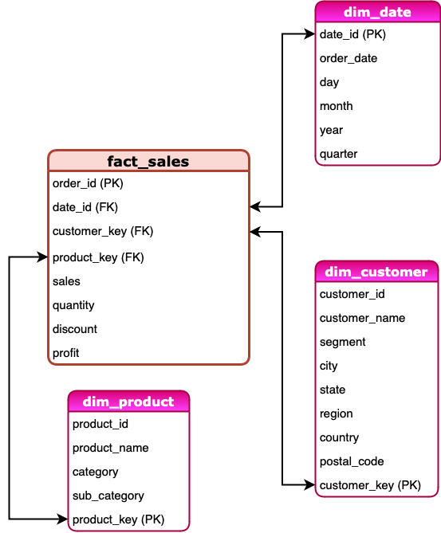

Tabulka **fact_sales** obsahuje cizí klíče na tabulky **dim_customer**, **dim_date** a **dim_product**, které slouží jako **dimenze**.

## 4.4 Import dat do PostgreSQL a vytvoření tabulek

Po přípravě souborů `dim_customer.csv`, `dim_date.csv`, `dim_product.csv` a `fact_sales.csv` jsem vytvořila novou databázi v PostgreSQL a importovala do ní všechny tabulky.

### Vytvoření databáze

Nejdříve jsem se přihlásila do PostgreSQL přes příkazový řádek a vytvořila novou databázi s názvem `OLAP`.

```sql
CREATE DATABASE OLAP;
```

Poté jsem se připojila k databázi `OLAP`:

```bash
\c OLAP
```

### Vytvoření tabulek

Následně jsem vytvořila jednotlivé tabulky odpovídající hvězdicovému schématu pomocí SQL příkazů.

#### Tabulka dim_customer:

```sql
CREATE TABLE dim_customer (
    customer_key SERIAL PRIMARY KEY,
    customer_id VARCHAR(50),
    customer_name VARCHAR(100),
    segment VARCHAR(50),
    city VARCHAR(50),
    state VARCHAR(50),
    region VARCHAR(50),
    country VARCHAR(50),
    postal_code VARCHAR(20)
);
```

#### Tabulka dim_date:

```sql
CREATE TABLE dim_date (
    date_id SERIAL PRIMARY KEY,
    order_date DATE,
    day INT,
    month INT,
    year INT,
    quarter INT
);
```

#### Tabulka dim_product:

```sql
CREATE TABLE dim_product (
    product_key SERIAL PRIMARY KEY,
    product_id VARCHAR(50),
    product_name VARCHAR(100),
    category VARCHAR(50),
    sub_category VARCHAR(50)
);
```

#### Tabulka fact_sales:

```sql
CREATE TABLE fact_sales (
    order_id VARCHAR(50),
    date_id INT REFERENCES dim_date(date_id),
    customer_key INT REFERENCES dim_customer(customer_key),
    product_key INT REFERENCES dim_product(product_key),
    sales NUMERIC,
    quantity INT,
    discount NUMERIC,
    profit NUMERIC
);
```

### Import dat z CSV

Po vytvoření tabulek jsem naimportovala data z připravených CSV souborů do databáze PostgreSQL pomocí příkazů `COPY`.

Soubor `dim_customer.csv`:

```sql
COPY dim_customer(customer_id, customer_name, segment, city, state, region, country, postal_code)
FROM '/Users/majdikleckerova/Desktop/OLAP – Superstore Sales/dim_customer.csv' DELIMITER ',' CSV HEADER;
```

Soubor `dim_date.csv`:

```sql
COPY dim_date(order_date, day, month, year, quarter)
FROM '/Users/majdikleckerova/Desktop/OLAP – Superstore Sales/dim_date.csv' DELIMITER ',' CSV HEADER;
```

Soubor `dim_product.csv`:

```sql
COPY dim_product(product_id, product_name, category, sub_category)
FROM '/Users/majdikleckerova/Desktop/OLAP – Superstore Sales/dim_product.csv' DELIMITER ',' CSV HEADER;
```

Soubor `fact_sales.csv`:

```sql
COPY fact_sales(order_id, date_id, customer_key, product_key, sales, quantity, discount, profit)
FROM '/Users/majdikleckerova/Desktop/OLAP – Superstore Sales/fact_sales.csv' DELIMITER ',' CSV HEADER;
```

Po úspěšném importu jsem zkontrolovala počet řádků v jednotlivých tabulkách pomocí SQL dotazu:

```sql
SELECT COUNT(*) FROM dim_customer;
SELECT COUNT(*) FROM dim_date;
SELECT COUNT(*) FROM dim_product;
SELECT COUNT(*) FROM fact_sales;
```

Tímto jsem dokončila vytvoření databáze `OLAP` s hvězdicovým schématem a nahráním všech dat do PostgreSQL.

# Připojení Metabase k databázi PostgreSQL

Po vytvoření databáze `OLAP` v PostgreSQL jsem přistoupila k propojení databáze s analytickým nástrojem **Metabase**, který jsem měla spuštěný v Docker kontejneru.

## 5.1 Spuštění Metabase

Metabase jsem spustila pomocí následujícího příkazu v terminálu:

```bash
docker run -d -p 3000:3000 --name metabase metabase/metabase
```

Aplikace se spustila na adrese http://localhost:3000, kde jsem otevřela **webové rozhraní Metabase**.

## 5.3 Ověření propojení

Po úspěšném připojení jsem v rozhraní Metabase viděla databázi `OLAP` a její jednotlivé tabulky:

- dim_customer
- dim_date
- dim_product
- fact_sales

Následně jsem otevřela **Databáze → OLAP → Prozkoumat data** a ověřila, že mohu procházet tabulky, zobrazit data i vytvářet dotazy.

## 5.4 Screenshot připojení

Screenshot rozhraní Metabase s potvrzením úspěšného připojení k databázi a viditelnými tabulkami:

[figure not shown]

Připojení Metabase k PostgreSQL

# 6. Dotazy nad datovou strukturou

V rámci analýzy jsem vytvořila několik různých **SQL dotazů** nad datovou strukturou.

Níže uvádím jednotlivé dotazy, jejich popis, SQL kód a očekávaný výstup.

## 6.1 Roční zisk podle regionu

```sql
SELECT
    c.region,
    ROUND(SUM(f.profit), 2) AS total_profit
FROM fact_sales f
JOIN dim_customer c ON f.customer_key = c.customer_key
JOIN dim_date d ON f.date_id = d.date_id
WHERE 1=1
  [[AND d.year = {{year}}]]
GROUP BY c.region
ORDER BY total_profit DESC;
```

**Ukázka výstupu:**

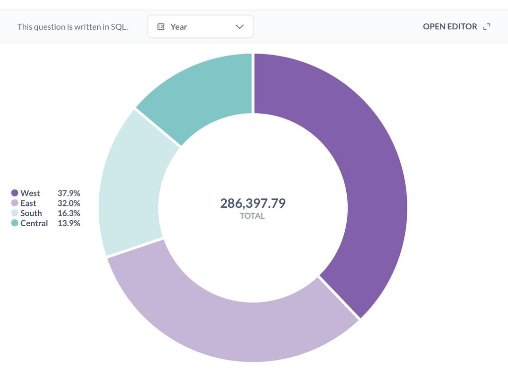

Výstup 6.1 – Zisk podle regionu

## 6.2 Ziskovost podle výše slev

Tento dotaz analyzuje, jak **různé úrovně slev** ovlivňují tržby, zisk a počet realizovaných prodejů.

Výše slevy je rozdělena do **kategorií** (např. 0–5 %, 5–10 %, atd.) a následně se pro každou kategorii vypočítá `celkový počet objednávek`, `obrat`, `zisk` a `ziskovost` (margin).

Taková analýza je cenná zejména pro marketing a cenotvorbu – pomáhá odhalit hranici, kde sleva ještě podporuje prodeje, ale zároveň už příliš neohrožuje celkovou ziskovost.

```sql
SELECT
  CASE
    WHEN f.discount BETWEEN 0.00 AND 0.05 THEN '0–5 %'
    WHEN f.discount BETWEEN 0.05 AND 0.10 THEN '5–10 %'
    WHEN f.discount BETWEEN 0.10 AND 0.20 THEN '10–20 %'
    WHEN f.discount BETWEEN 0.20 AND 0.30 THEN '20–30 %'
    WHEN f.discount > 0.30 THEN '30+ %'
    ELSE 'Unknown'
  END AS discount_range,
  CASE
    WHEN f.discount BETWEEN 0.00 AND 0.05 THEN 1
    WHEN f.discount BETWEEN 0.05 AND 0.10 THEN 2
    WHEN f.discount BETWEEN 0.10 AND 0.20 THEN 3
    WHEN f.discount BETWEEN 0.20 AND 0.30 THEN 4
    WHEN f.discount > 0.30 THEN 5
    ELSE 6
  END AS sort_order,
  COUNT(*) AS number_of_sales,
  SUM(f.sales) AS total_sales,
  SUM(f.profit) AS total_profit,
  ROUND(SUM(f.profit) / NULLIF(SUM(f.sales), 0), 2) AS profit_margin
FROM fact_sales f
GROUP BY discount_range, sort_order
ORDER BY sort_order;
```

**Ukázka výstupu:**

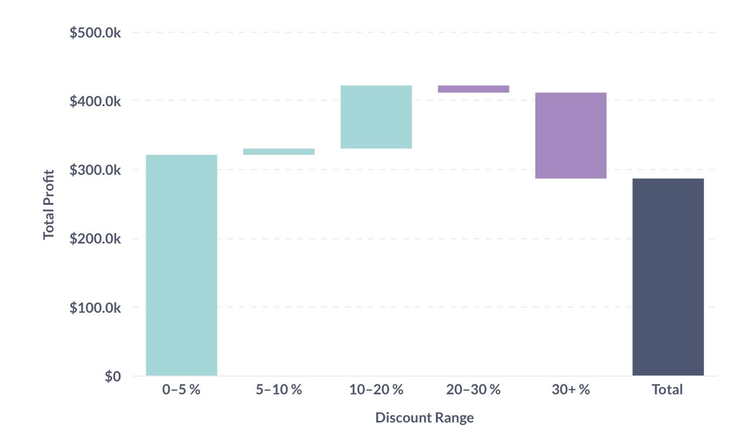

Výstup 6.2 – Zisk podle slevy

## 6.3 Výkon prodeje podle státu, roku a kategorie

Tento dotaz shrnuje výkonnost prodeje podle **geografické oblasti (státu)**, **časového úseku (roku)** a **produktové kategorie**.

Zahrnuje jak absolutní metriky (`sales`, `profit`, `počet objednávek`), tak jejich **zaokrouhlené verze**, které umožňují jednodušší seskupení v grafech.

Součástí dotazu je i podmínka pro **filtrování podle roku** (parametr `{{year}}`).

```sql
SELECT
  c.state,
  d.year,
  p.category,
  SUM(f.sales) AS total_sales,
  SUM(f.profit) AS total_profit,
  COUNT(DISTINCT f.order_id) AS total_orders,
  FLOOR(SUM(f.profit) / 5000) * 5000 AS rounded_profit,
  FLOOR(SUM(f.sales) / 10000) * 10000 AS rounded_sales,
  FLOOR(COUNT(DISTINCT f.order_id) / 50) * 50 AS rounded_orders
FROM fact_sales f
JOIN dim_customer c ON f.customer_key = c.customer_key
JOIN dim_date d ON f.date_id = d.date_id
JOIN dim_product p ON f.product_key = p.product_key
WHERE 1=1
[[AND d.year = {{year}}]]
GROUP BY c.state, d.year, p.category
ORDER BY total_profit DESC;
```

**Ukázka výstupu:**

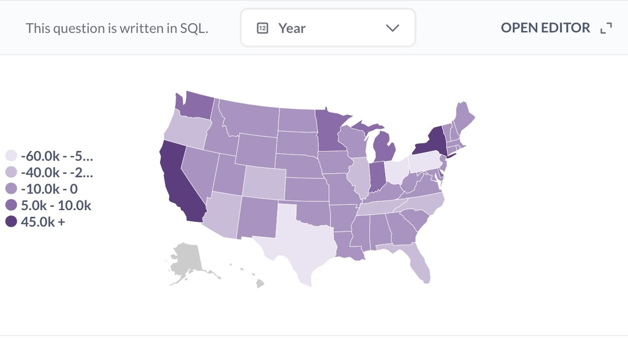

Výstup 6.3 – Výkon podle států

## 6.4 Čtvrtletní zisk podle segmentu

Tento dotaz umožňuje analyzovat, jaký byl zisk v jednotlivých **čtvrtletích** a jak se lišil mezi zákaznickými segmenty.

Pomáhá zachytit **sezónní trendy** a porovnat vývoj segmentů **v průběhu roku**.

```sql
SELECT
    CONCAT(d.year, '-Q', d.quarter) AS year_quarter,
    c.segment,
    ROUND(SUM(f.profit), 2) AS total_profit
FROM fact_sales f
JOIN dim_date d ON f.date_id = d.date_id
JOIN dim_customer c ON f.customer_key = c.customer_key
JOIN dim_product p ON f.product_key = p.product_key
GROUP BY d.year, d.quarter, c.segment
ORDER BY d.year, d.quarter, c.segment;
```

**Ukázka výstupu:**

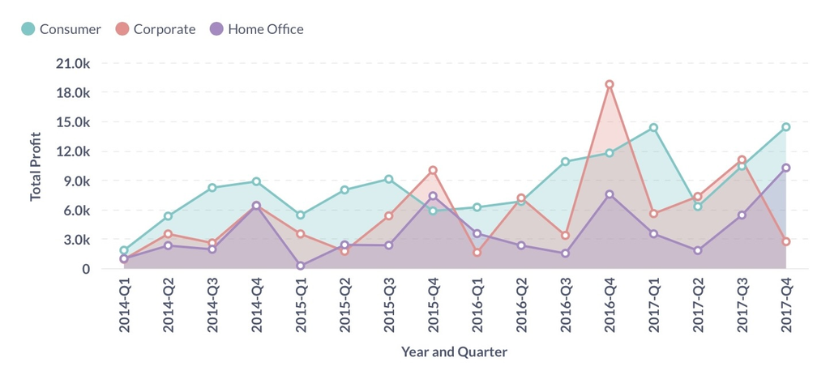

Výstup 6.4 – Zisk podle čtvrtletí

## 6.5 Nejziskovější podkategorie

Dotaz vrací **8 podkategorií produktů s nejvyšším ziskem**, včetně **průměrné výše slevy** v dané skupině.

```sql
SELECT
    p.sub_category,
    ROUND(SUM(f.profit), 2) AS total_profit,
    ROUND(AVG(f.discount) * 100, 1) AS avg_discount_percent
FROM fact_sales f
JOIN dim_product p ON f.product_key = p.product_key
JOIN dim_date d ON f.date_id = d.date_id
WHERE 1=1
  [[AND d.year = {{year}}]]
GROUP BY p.sub_category
ORDER BY total_profit DESC
LIMIT 8;
```

**Ukázka výstupu:**

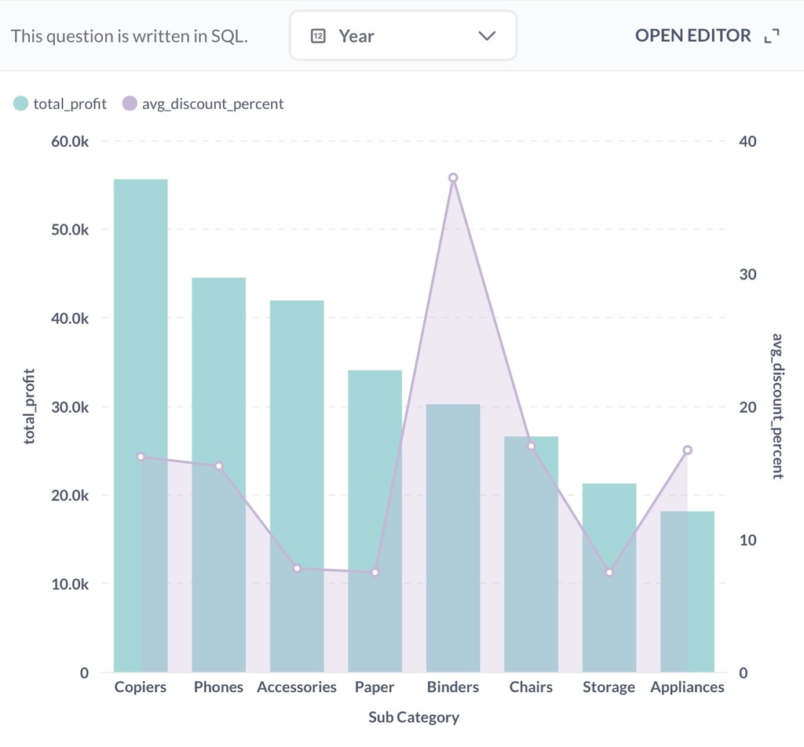

Výstup 6.5 – Nejziskovější podkategorie

## 6.6 Nejvýkonnější města v daném státě

Tento dotaz analyzuje prodeje na úrovni jednotlivých měst, s možností **filtrování podle konkrétního státu**.

```sql
SELECT
    dim_customer.city,
    ROUND(SUM(fact_sales.sales), 2) AS total_sales
FROM fact_sales
JOIN dim_customer ON fact_sales.customer_key = dim_customer.customer_key
WHERE 1=1
  [[AND {{state}}]]
GROUP BY dim_customer.city
ORDER BY total_sales DESC
LIMIT 10;
```

**Ukázka výstupu:**

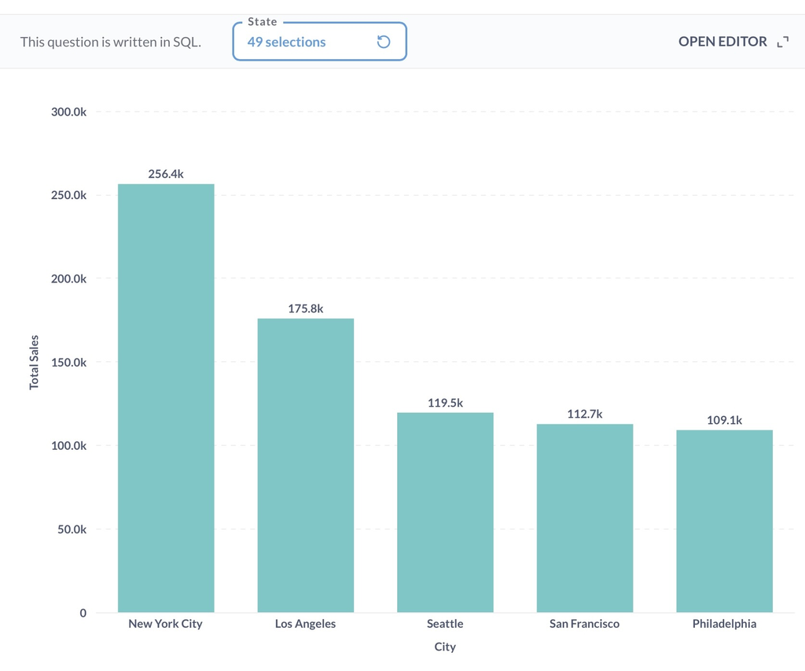

Výstup 6.6 – Nejvýkonnější města

# 8. Krok 8 – Aplikace metod data miningu

V závěrečné části práce jsem aplikovala **dvě odlišné metody data miningu**:

- **shlukování zákazníků (Clustering)** – metoda neřízeného učení, která hledá skupiny zákazníků s podobným chováním,
- **rozhodovací strom (Decision Tree)** – klasifikační metoda, která slouží k predikci ziskovosti jednotlivých objednávek.

Obě analýzy byly implementovány v jazyce **Python** a využívaly propojení na relační databázi **PostgreSQL**, kde byla uložena datová struktura ve formě **hvězdicového schématu**.

## 8.1 Segmentace zákazníků pomocí shlukování (Clustering)

### Co je shlukování?

Shlukování (angl. *clustering*) je metoda neřízeného strojového učení, která rozděluje záznamy do **skupin (shluků)** na základě podobnosti. Cílem je nalézt přirozené struktury ve vstupních datech bez předem známé výstupní proměnné.

V této analýze jsem shlukovala **zákazníky** podle jejich **nákupního chování**. Výsledkem jsou skupiny zákazníků, které sdílejí podobné obchodní charakteristiky a mohou být využity např. při cílení marketingu, personalizaci nabídky nebo plánování zásob.

### Použité numerické atributy:

1. **`total_sales`** – celková útrata zákazníka
2. **`total_profit`** – celkový výdělek pro firmu
3. **`avg_discount`** – průměrná výše slevy
4. **`total_quantity`** – celkový počet zakoupených kusů
5. **`count_orders`** – celkový počet objednávek

Každý zákazník byl popsán těmito pěti číselnými hodnotami, což znamená, že tvořil **jeden bod v pětidimenzionálním prostoru**.

### Postup:

1. **Načtení a agregace dat** z databáze PostgreSQL pomocí SQL dotazu.
2. **Výběr numerických atributů** pro každého zákazníka.
3. **Standardizace dat** (pomocí `StandardScaler`) – z důvodu odlišných jednotek a rozsahů hodnot.
4. **Určení optimálního počtu shluků** pomocí Elbow metody – sleduje se pokles přesnosti, tzv. „inertia“.
5. **Rozdělení zákazníků do shluků** pomocí algoritmu KMeans.
6. **Vizualizace výsledků** v redukovaném 2D prostoru pomocí PCA (Principal Component Analysis).

### Kód:

```python
## Načtení knihoven
from sqlalchemy import create_engine
import pandas as pd
import matplotlib.pyplot as plt
from sklearn.preprocessing import StandardScaler
from sklearn.cluster import KMeans
from sklearn.decomposition import PCA


## Propojení s db
username = "postgres"
password = "postgres"
host = "localhost"
port = "5432"
database = "OLAP"
connection_string = f"postgresql+psycopg2://{username}:{password}@{host}:{port}/{database}"
engine = create_engine(connection_string)


## Agregace zákazníků
query = """
SELECT
    c.customer_id,
    c.customer_name,
    c.segment,
    c.region,
    SUM(f.sales) AS total_sales,
    SUM(f.profit) AS total_profit,
    AVG(f.discount) AS avg_discount,
    SUM(f.quantity) AS total_quantity,
    COUNT(DISTINCT f.order_id) AS count_orders
FROM fact_sales f
JOIN dim_customer c ON f.customer_key = c.customer_key
GROUP BY c.customer_id, c.customer_name, c.segment, c.region;
"""
df = pd.read_sql(query, engine)
#print("\nPrvních 5 řádků načtených dat:\n")
#print(df.head())


## Atributy pro shlukování
numericke_atributy = ['total_sales', 'total_profit', 'avg_discount', 'total_quantity', 'count_orders']
X = df[numericke_atributy]


## Standardizace dat
scaler = StandardScaler()
X_scaled = scaler.fit_transform(X)


## Elbow metoda pro určení optimálního počtu shluků
inertia = []
range_n_clusters = range(1, 10)
for k in range_n_clusters:
    kmeans = KMeans(n_clusters=k, random_state=42)
    kmeans.fit(X_scaled)
    inertia.append(kmeans.inertia_)


### Graf (Elbow metoda)
plt.figure(figsize=(5,3))
ax = plt.gca()
ax.set_facecolor('#f7f7f7')
ax.grid(True, color='white', linewidth=1.5)
ax.spines['top'].set_visible(False)
ax.spines['right'].set_visible(False)
plt.plot(
    range_n_clusters, inertia,
    marker='o', markersize=10, linewidth=2.5,
    color='hotpink')
plt.xlabel('Počet shluků (k)', fontsize=14, fontweight="bold")
plt.ylabel('Inertia', fontsize=14, fontweight="bold")
plt.title('Elbow metoda pro výběr optimálního počtu shluků', fontsize=16, fontweight="bold")
plt.xticks(fontsize=12)
plt.yticks(fontsize=12)
print("\nVizualizace Elbow metody pro určení počtu shluků:\n")
plt.show()

## Rozdělení do shluků
optimal_k = 3
### KMeans shlukování
kmeans = KMeans(n_clusters=optimal_k, random_state=42)
df['cluster'] = kmeans.fit_predict(X_scaled)
print(f"\nPočet zákazníků v každém shluku:\n{df['cluster'].value_counts()}")
print("\nPrůměrné hodnoty metrik pro každý shluk:\n")
print(df.groupby('cluster')[numericke_atributy].mean())

## PCA redukce na 2D pro vizualizaci
pca = PCA(n_components=2)
X_pca = pca.fit_transform(X_scaled)

## Graf (Vizualizace shluků)
plt.figure(figsize=(12,8))
ax = plt.gca()
ax.set_facecolor('#f7f7f7')
ax.grid(True, color='white', linewidth=1.5)
ax.spines['top'].set_visible(False)
ax.spines['right'].set_visible(False)
plt.xlabel('První hlavní komponenta', fontsize=14, fontweight="bold")
plt.ylabel('Druhá hlavní komponenta', fontsize=14, fontweight="bold")
plt.title('Vizualizace shlukování zákazníků (PCA)', fontsize=16, fontweight='bold')
scatter = plt.scatter(
    X_pca[:,0], X_pca[:,1],
    c=df['cluster'], cmap='RdPu',
    edgecolor='black', s=100, alpha=0.8
)
cbar = plt.colorbar(scatter, label='Cluster')
cbar.ax.tick_params(labelsize=12)
print("\nVizualizace shluků po PCA redukci do dvourozměrného prostoru:\n")
plt.show()
```

### Výsledky:

Byly identifikovány **3 shluky zákazníků**:

- **Shluk 0**: menší zákazníci, nízké tržby i zisk, málo využívají slevy – přinášejí stabilní, ale nižší hodnotu.
- **Shluk 1**: střední zákazníci, častější objednávky, vysoké slevy – v průměru ztrátová skupina.
- **Shluk 2**: klíčoví zákazníci – vysoké tržby i zisk, mírné slevy, vysoká hodnota.

**Elbow metoda – výběr počtu shluků:**

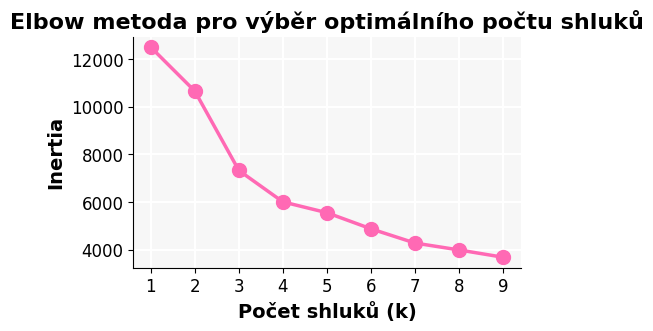

**Souhrnná tabulka průměrných hodnot pro každý shluk:**

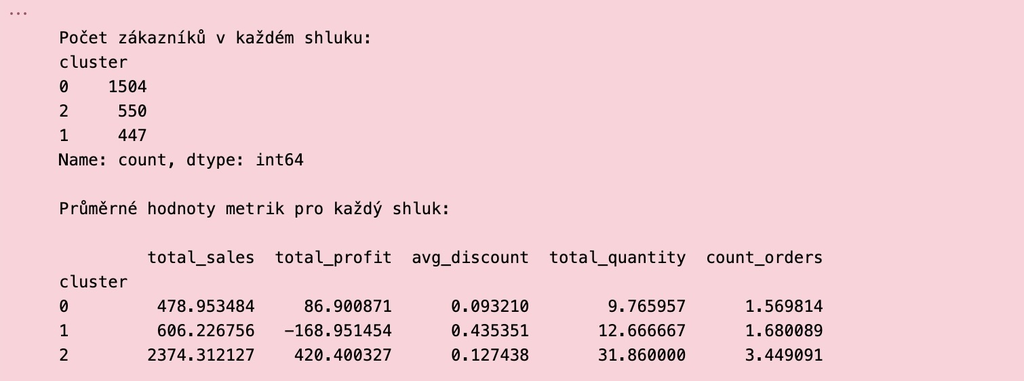

**PCA vizualizace rozdělení zákazníků do shluků:**

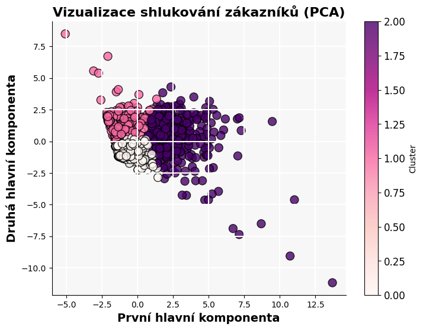

## 8.2 Predikce ziskovosti objednávek pomocí rozhodovacího stromu (Decision Tree)

### Co je rozhodovací strom?

**Rozhodovací strom** (angl. *decision tree*) je metoda řízeného učení, která umožňuje klasifikovat objekty do kategorií na základě sekvence rozhodnutí. Strom se skládá z **uzlů**, které představují rozhodovací podmínky, a **větví**, které odpovídají možným výsledkům.

Cílem této analýzy bylo vytvořit model, který dokáže **na základě vlastností objednávky** odhadnout, zda bude objednávka **zisková (`profit > 0`)**, nebo **nezisková**.

### Použité atributy (vstupy):

- `segment` – typ zákazníka (zakódováno číselně)
- `category` – hlavní produktová kategorie
- `sub_category` – podkategorie produktu
- `quantity` – počet kusů v objednávce
- `discount` – poskytnutá sleva

Výstupní proměnná (`target`) byla binární:  
- **`is_profitable = 1`** → objednávka generuje zisk  
- **`is_profitable = 0`** → objednávka je ztrátová

### Postup:

1. **Načtení dat** z databáze PostgreSQL přes SQLAlchemy.
2. **Vytvoření cílové proměnné** `is_profitable` (pomocí podmínky `profit > 0`).
3. **Zakódování kategorií** pomocí `LabelEncoder`.
4. **Rozdělení dat** na trénovací a testovací množinu (`train_test_split`).
5. **Natrénování modelu** rozhodovacího stromu (`DecisionTreeClassifier`).
6. **Vyhodnocení přesnosti modelu** na testovací sadě.
7. **Vizualizace rozhodovacího stromu** pomocí `plot_tree`.

### Kód

```python
## Načtení knihoven
from sqlalchemy import create_engine
import pandas as pd
from sklearn.model_selection import train_test_split
from sklearn.preprocessing import LabelEncoder
from sklearn.tree import DecisionTreeClassifier, plot_tree
import matplotlib.pyplot as plt


## Připojení k databázi
username = "postgres"
password = "postgres"
host = "localhost"
port = "5432"
database = "OLAP"
connection_string = f"postgresql+psycopg2://{username}:{password}@{host}:{port}/{database}"
engine = create_engine(connection_string)


## Načtení dat
query = """
SELECT
    f.order_id,
    c.segment,
    p.category,
    p.sub_category,
    f.quantity,
    f.discount,
    f.profit
FROM fact_sales f
JOIN dim_customer c ON f.customer_key = c.customer_key
JOIN dim_product p ON f.product_key = p.product_key;
"""
df = pd.read_sql(query, engine)
#print("\nPrvních 5 řádků dat:\n")
#print(df.head())


## Přidání cílové proměnné: is_profitable
df['is_profitable'] = (df['profit'] > 0).astype(int)


## Kódování kategorií (label encoding)
le_segment = LabelEncoder()
le_category = LabelEncoder()
le_sub_category = LabelEncoder()
df['segment_enc'] = le_segment.fit_transform(df['segment'])
df['category_enc'] = le_category.fit_transform(df['category'])
df['sub_category_enc'] = le_sub_category.fit_transform(df['sub_category'])


## Výběr atributů
features = ['segment_enc', 'category_enc', 'sub_category_enc', 'quantity', 'discount']
X = df[features]
y = df['is_profitable']


## Rozdělení na trénovací a testovací sadu
X_train, X_test, y_train, y_test = train_test_split(X, y, test_size=0.3, random_state=42)


## Trénování rozhodovacího stromu
clf = DecisionTreeClassifier(max_depth=3, random_state=42)
clf.fit(X_train, y_train)


## Vyhodnocení přesnosti
accuracy = clf.score(X_test, y_test)
print(f"\nPřesnost modelu na testovací sadě: {accuracy:.2f}\n")


## Vizualizace rozhodovacího stromu
plt.figure(figsize=(20,10))
ax = plt.gca()
ax.set_facecolor('#f7f7f7')
plot_tree(
    clf,
    feature_names=features,
    class_names=['Nezisková', 'Zisková'],
    filled=True,
    rounded=True,
    fontsize=12,
    impurity=False,
    node_ids=False,
    label='all',
    proportion=True,
)
plt.title('Rozhodovací strom: predikce ziskovosti objednávky', fontsize=16, fontweight='bold')
print("\n Vizualizace rozhodovacího stromu:\n")
plt.show()
```

### Výsledky:

Model dosáhl velmi solidní přesnosti na testovacích datech **(0.93)** a vizualizace stromu poskytuje srozumitelný a transparentní popis, jak se jednotlivé atributy podílejí na rozhodování.

**Výstup – přesnost klasifikace:**

[output not shown]

**Vizualizace rozhodovacího stromu:**

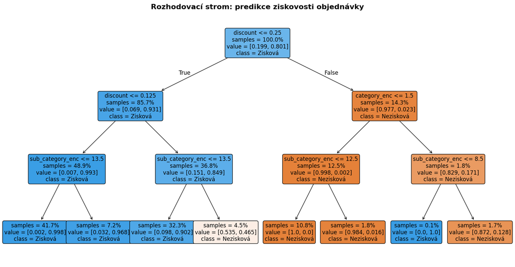

### Shrnutí:

Obě metody ukázaly, že data v databázi lze efektivně využít nejen pro deskriptivní analýzu, ale i pro **automatizované rozhodování a rozpoznávání vzorců**:

- Clustering odhalil **skupiny zákazníků** s různým obchodním profilem.
- Rozhodovací strom umožnil **předvídat ziskovost** objednávek na základě známých vlastností.

Tyto přístupy lze dále rozvíjet a integrovat do BI nástrojů, marketingových strategií nebo doporučovacích systémů.

# 9. Závěr

Cílem této seminární práce bylo seznámit se s nástroji a principy OLAP analýzy a datového miningu a aplikovat je na konkrétní datovou sadu uloženou v relační databázi. V průběhu práce jsem prošla kompletním datovým procesem – od výběru dat až po pokročilé analytické techniky a vizualizaci výstupů.

## Přínos a zhodnocení

Získala jsem praktické zkušenosti s návrhem datového skladu, tvorbou dotazů a implementací analytických metod nad skutečnými obchodními daty.

Současně jsem si uvědomila, jak důležitá je správná příprava dat – čištění, agregace a strukturování – která je často časově nejnáročnější částí celého procesu.

# 10. Seznam zdrojů

1. **Superstore Dataset Final** [online]. [cit. 2025-05-11]. Dostupné z: https://www.kaggle.com/datasets/vivek468/superstore-dataset-final
2. **Metabase** [online]. Metabase Inc., 2025 [cit. 2025-05-11]. Dostupné z: https://www.metabase.com/
3. **PostgreSQL Documentation** [online]. The PostgreSQL Global Development Group, 2025 [cit. 2025-05-11]. Dostupné z: https://www.postgresql.org/docs/
4. **Scikit-learn: Machine Learning in Python** [online]. [cit. 2025-05-11]. Dostupné z: https://scikit-learn.org/
5. **Comparison of OLAP servers** [online]. Wikipedia, 2025 [cit. 2025-05-11]. Dostupné z: https://en.wikipedia.org/wiki/Comparison_of_OLAP_servers
6. **Online Analytical Processing (OLAP)** [online]. DataCamp, 2024 [cit. 2025-05-11]. Dostupné z: https://www.datacamp.com/tutorial/what-is-olap
7. **K-Means Clustering Algorithm** [online]. Analytics Vidhya, 2019 [cit. 2025-05-11]. Dostupné z: https://www.analyticsvidhya.com/blog/2019/08/comprehensive-guide-k-means-clustering/
8. **Decision Tree Classification in Python** [online]. DataCamp, 2024 [cit. 2025-05-11]. Dostupné z: https://www.datacamp.com/tutorial/decision-tree-classification-python